# The First Model

When backtesting the model you must:

- Describe what you want to do
- Write a program for executing it
- Get results and analyze the model's statistics

With package `stratbuilder2pub` you can do it easily:

- We provide tools for creating any midterm financial model
- Your program will have a clear interface
- You will get statistics in the form of tables and interactive graphs

This document introduces to you basic set of tools of this package.

## The First Model

Let's create a simple mean-reverting strategy using technical indicators from package `TTR`. Take two moving averages of adjusted close prices of an asset. One of them will be with a small window (fast ma), and one will be with a big window (slow ma). If fast ma bigger than slow ma, than we should hold the short position. If fast ma is less than slow ma, then we should hold the long position. And we will not trade against the long trend, we will define it through very slow ma(moving average with big window).

So, firstly, create an empty model.

```r
this <- modelStrategy()
```

Backtester uses internal names. One of them is `spread`. It is the central element of every model. For its definition firstly we should define a table from that it will be calculated. Spread will be equal to linier combination of columns of that table. To get coefficients of that combination we should define a function that will calculate coefficients. If only one asset is used in the model, the table usually equals to close or adjusted prices, function for coefficients always return 1, then spread usually equals to close or adjusted prices.

In our model `spread` will be equal to adjusted prices of an asset, that we will determine later. Now we need to define indicators, that will be used in backtest. Let's use Exponential Moving Average as moving averages, for this `TTR` has a function `EMA`. It has 2 arguments `x` and `n`. `x` responsible for time-series to filter and `n` for size of window. As we want to use `spread` as `x` and it is not defined at this step, we will use `quote` function for making possible to substitute `spread` to `EMA` when it will be evaluated. `args` argument is a list. The first element of it contains function, other elements are function's argumens. `as` argument is the name of indicator. This name can be used later in other indicators and rules.

```r
addIndicator(this, args = list(name = EMA, x = quote(spread), n = 20), as = 'fast_ma')
addIndicator(this, args = list(name = EMA, x = quote(spread), n = 100), as = 'slow_ma')
addIndicator(this, args = list(name = EMA, x = quote(spread), n = 250), as = 'very_slow_ma')
```

So, we defined indicators, now let's create rules for enter to position and exit from it. Start with enterance to short position. In `condition` argument we must write logical expression indicating when condition is satisfied. For our strategy it is `fast_ma > slow_ma & Diff(very_slow_ma, 1) < 0`. In this place we do not have to use `quote` function, just write a condition. `Diff` function returns diffrence between series and lagged version of it. `type` argument must be one of “enter” or “exit”, specifying enter to position or exiting from it. In our setting it is “enter”. As we want to short asset `side` argument will be assigned to -1. And the last argument `oco` is responsible for environment of the rule. Rules with the same `oco` works together. For example, if position was open by the rule with `oco` that equals to “long”, then position can only be closed by the rule with the same 'oco'.

```r
addRule(this,
        condition = fast_ma > slow_ma & Diff(very_slow_ma, 1) < 0,
        type = 'enter',
        side = -1,
        oco = 'short'
)
```

```r
addRule(this,
        condition = !(fast_ma > slow_ma & Diff(very_slow_ma, 1) < 0),
        type = 'exit',
        oco = 'short'
)
```

For long position we should add analogious rules. Note that `side` is equal to 1 now and we use another `oco`.

```r
addRule(this,
        condition = fast_ma < slow_ma & Diff(very_slow_ma, 1) > 0,
        type = 'enter',
        side = 1,
        oco = 'long'
)
addRule(this,
        condition = !(fast_ma < slow_ma & Diff(very_slow_ma, 1) > 0),
        type = 'exit',
        oco = 'long'
)
```

At this step we almost completly describe strategy. It remains only to set amount of money and prices. Money is expressed in the same currency as the used data. Data in multiple currencies is not supported now, but there are ways to overcome this issue. As we will use data in USD we forget about this. For downloading data we will use `quantmod`. In this strategy we only use adjusted prices, so in `setUserData` the second argument is equal to `Ad(data)`.

```r
data <- getSymbols('RSX', from = Sys.Date() - 365 * 10, src = 'yahoo', auto.assign = FALSE)
setUserData(this, Ad(data))
setMoney(this, 100000)
```

Now evaluate model. Evaluation will be done on the server. Client and server connect via ssh. All statistics of evaluated model will be inserted to your object `this` after evaluation ends.

```r
performServer(this)
```

## Reports

After completion of evaluation you can get results of the strategy. It is important to know how strategy is performing and how stably it can make a profit. When you look at the PnL graph you can understand almost everything about your strategy.

The first plot is the profit and loss graph. It shows the cost of all instruments plus cash on your account at every moment through a period of backtesting.

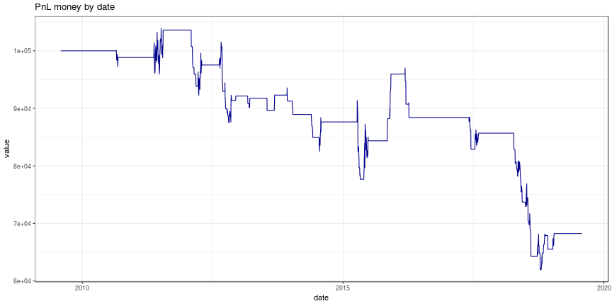

```r
plotPnL(this, interactive_plot=FALSE)
```

Also, there is a possibility to return PnL by months in the format of the coloured table.

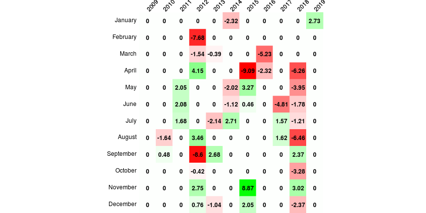

```r
plotCalendar(this)
```

The next graph is about how much money your strategy uses.

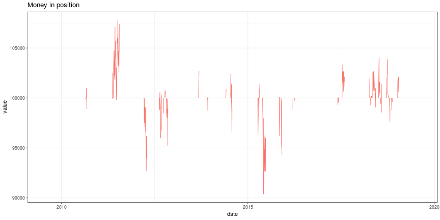

```r
plotCapital(this, interactive_plot=FALSE)
```

You can see that there are multiple separated lines. Every line is responsible for a single trade, of course if some time was between opening and closing trades. The next graph was made to demonstrate the performance of every trade in one plot. Each triangle is a trade. If it is green, then the trade is positive, else it is negative. X-axis shows the absolute value of the profit and loss for trades and Y-axis is the maximum amount of loss that was available while a trade was open. And you can change Y-axis to MFE which means the maximum amount of profit that was available while a trade was open.

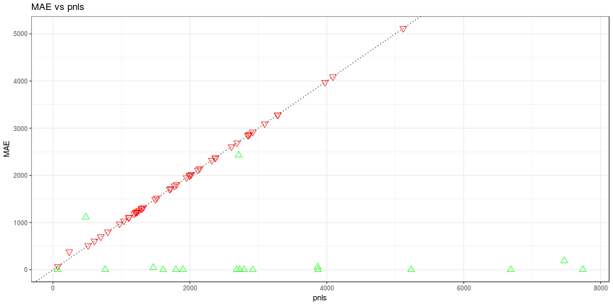

```r
plotReturns(this, "MAE", interactive_plot=FALSE)
```

You can get information for each trade in the format of table with the help of `getReportTrades` command.

```r
head(getReportTrades(this))
```

```
#>   ind.start ind.end date.start   date.end side beta.RSX.Adjusted
#> 1       267     269 2010-08-24 2010-08-26   -1                 1
#> 2       270     271 2010-08-27 2010-08-30    1                 1
#> 3       273     277 2010-09-01 2010-09-08    1                 1
#> 4       450     455 2011-05-16 2011-05-23    1                 1
#> 5       457     497 2011-05-25 2011-07-22    1                 1
#> 6       631     632 2012-02-02 2012-02-03   -1                 1
#>   price.start.RSX.Adjusted price.end.RSX.Adjusted pnl.asset.RSX.Adjusted
#> 1                 22.90218               22.88680               67.13598
#> 2                 23.44802               23.04825            -1704.61502
#> 3                 24.10149               24.21681              478.45853
#> 4                 28.43805               27.67321            -2689.16338
#> 5                 28.54620               30.67848             7469.34882
#> 6                 24.46139               25.16389            -2871.82409
#>   com.asset.RSX.Adjusted com.sum     pnl.sum pnl.sum.adj spread.price
#> 1                      0       0    67.13598    67.13598     99990.92
#> 2                      0       0 -1704.61502 -1704.61502     99982.34
#> 3                      0       0   478.45853   478.45853    100985.88
#> 4                      0       0 -2689.16338 -2689.16338    102514.36
#> 5                      0       0  7469.34882  7469.34882    107764.41
#> 6                      0       0 -2871.82409 -2871.82409     99998.16
#>   MAE.with.com MFE.with.com return.from.money
#> 1       0.0000     100.7062      0.0006714208
#> 2    1704.6150       0.0000     -0.0170491603
#> 3    1116.3839     988.8187      0.0047378753
#> 4    2689.1634    2526.1897     -0.0262320653
#> 5     189.4387    7767.0548      0.0693118349
#> 6    2871.8241       0.0000     -0.0287187686
```

And tables of statistics. Every statistic described in help, just enter `?getReportStrategy` or `?getReportCalendar`. The first report has results for whole period of backtesting, the second report – for every year.

```r
getReportStrategy(this)
```

```
#>                      [,1]
#> trades                 65.0000
#> trades.year             7.0000
#> long.trades            27.0000
#> short.trades           38.0000
#> long.acc                0.2963
#> short.acc               0.2632
#> total.acc               0.2769
#> max.loose              11.0000
#> max.win                 3.0000
#> return.ann             -0.0318
#> return.avg             -0.2729
#> return.pos.drawdown    -0.0212
#> drawdown.money          0.3909
#> days.in.drawdown     2947.0000
#> median                 -0.0121
#> in.pos                  0.1165
#> in.pos.positive         0.7059
#> days.in.pos.max        58.0000
#> days.in.pos.mean        6.5385
#> days.out.pos.max      420.0000
#> days.out.pos.mean      41.2969
#> sharpe.ann             -0.3751
#> sortino.ann            -0.7437
#> maxMAE.money            0.0477
#> profit.drawdown.year   -0.0757
```

```r
getReportCalendar(this)
```

```
#>    year     sharpe return.pos.drawdown return.avg   return.ann
#> 1  2009        NaN                 NaN        NaN  0.000000000
#> 2  2010 -0.3545653        -0.011285225 -0.3510269 -0.011718628
#> 3  2011  0.4330500         0.042011212  0.2597199  0.048331515
#> 4  2012 -0.9710346        -0.098700551 -0.4613431 -0.115308148
#> 5  2013 -0.1844435        -0.008516221 -0.2501832 -0.008961857
#> 6  2014 -0.5832962        -0.032747380 -0.5498575 -0.036405151
#> 7  2015  0.6229240         0.072720667  0.4861653  0.083720736
#> 8  2016 -1.4149995        -0.070300981 -5.5169061 -0.076359218
#> 9  2017 -0.4984133        -0.025371575 -0.2801077 -0.027632682
#> 10 2018 -1.7400589        -0.158819471 -0.6981464 -0.202874558
#> 11 2019  1.7245102         0.045633854  1.0933225  0.047173310
#> 12    0 -0.3703510        -0.026531049 -0.6751583 -0.032072667
#>    return.drawdown days
#> 1              NaN  149
#> 2       -0.4060229  365
#> 3        0.6566264  365
#> 4       -0.7121912  366
#> 5       -0.3522572  365
#> 6       -0.4132490  365
#> 7        0.6076457  365
#> 8       -0.8759316  366
#> 9       -0.4895024  365
#> 10      -0.8496035  365
#> 11       2.1600040  211
#> 12      -0.1591485    0
```

## Optimization

The backtester provide tools for brute force optimization. For example, we can optimize window of moving averages. All available fields for optimazation can be seen via `?addDistribution`.

```r
addDistribution(this,
                component.type = 'indicator',
                component.label = 'fast_ma',
                variable = list(n = seq(5, 50, 5)),
                label = 'fast.n')
addDistribution(this,
                component.type = 'indicator',
                component.label = 'slow_ma',
                variable = list(n = seq(40, 150 , 10)),
                label = 'slow.n')
```

This function has multiple arguments. Component.type is a place from where variables come. There are multiple places where you can define variables and then iterate over them. Indicators are one of them. Component.label is the name of a specific component. It is needed if there were two or more indicators and you want to point one of them. Variable is a list that stores your distribution. In this example we want to choose size of window for indicators, the name of this argument is `n`, so in the list we should write `n` as the name of a list's cell. Label is just the name of your distribution. This name can be used in `addDistributionConstraint` function. We can see that our distributions intersect and we want slow window to be larger than fast window. So we can write.

```r
addDistributionConstraint(this,
                          expr = fast.n < slow.n)
```

Also, our indicator has an argument `name`. That argument contains a function, that creates an indicator. In addDistribution we can iterate over different functions too. And you can select multiple labels in `component.label` argument. So our indicators will have the same functions but with different windows. `label` argument can be omitted if it is unnecessary.

```r
addDistribution(this,
                component.type = 'indicator',
                component.label = c('fast_ma', 'slow_ma'),
                variable = list(name = c(EMA, SMA, DEMA)))
```

To erase old distributions you can call `deleteParamset` function.

To start iteration you need to call `applyParamsetServer` function. It has `start_date` and `end_date` arguments, they indicate the date of start and date of the end of backtesting. If they are missed, then backtest will be done on the whole period of downloaded data. Also, there is `nsamples` argument. It indicates how many samples from your distributions to select.

```r
applyParamsetServer(this,
                    nsamples = 5,
                    start_date = '2011-01-01',
                    end_date = '2017-01-01',
                    seed = 42)
```

After completion of procedure you can get results of backtesting this samples. The first part of this table consist of columns with values of distributions, other columns are statistics from `getReportStrategy`.

```r
getBacktestResults(this)
```

```
#>   index params.fast.n params.slow.n params.distribution3 trades
#> 1   330            50           120                 DEMA     42
#> 2   337            35           130                 DEMA     43
#> 3   103            15           140                  EMA     39
#> 4   297            35            90                 DEMA     41
#> 5   229            45           140                  SMA     36
#>   trades.year long.trades short.trades long.acc short.acc total.acc
#> 1           7           8           34   0.2500   0.20590   0.21430
#> 2           7          11           32   0.1818   0.25000   0.23260
#> 3           7          10           29   0.4000   0.27586   0.30769
#> 4           7          14           27   0.3571   0.18520   0.24390
#> 5           6          15           21   0.2667   0.23810   0.25000
#>   max.loose max.win return.ann return.avg return.pos.drawdown
#> 1        14       3   -0.04950   -0.17190            -0.03070
#> 2         6       2   -0.04640   -0.15970            -0.02880
```

[output cut: 21 more lines]

With help of library `dplyr` you can sort, filter, add new columns to that table and then select best parameters. Also you can use `View` function to see table in full screen. The first column is index of sample. You can evaluate strategy with specific index, then parameters by this index will be inserted to your strategy.

```r
performServer(this,
              paramset.index = 103,
              start_date = '2011-01-01',
              end_date = '2017-01-01')
getReportStrategy(this)
```

```
#>                      [,1]
#> trades                 39.00000
#> trades.year             7.00000
#> long.trades            10.00000
#> short.trades           29.00000
#> long.acc                0.40000
#> short.acc               0.27586
#> total.acc               0.30769
#> max.loose               6.00000
#> max.win                 3.00000
#> return.ann             -0.01223
#> return.avg             -0.15067
#> return.pos.drawdown    -0.00985
#> drawdown.money          0.16418
#> days.in.drawdown     1792.00000
#> median                 -0.01113
#> in.pos                  0.08135
#> in.pos.positive         0.58989
#> days.in.pos.max        20.00000
#> days.in.pos.mean        4.56410
#> days.out.pos.max      259.00000
#> days.out.pos.mean      42.31579
#> sharpe.ann             -0.15409
#> sortino.ann            -0.32532
#> maxMAE.money            0.04867
#> profit.drawdown.year   -0.07158
```

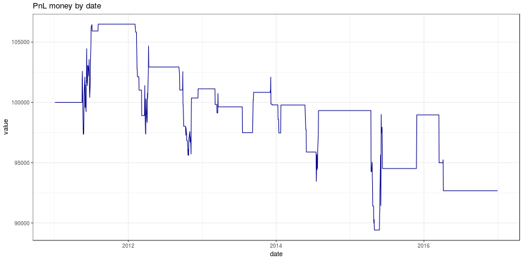

```r
plotPnL(this, interactive_plot=FALSE)
```

## Multiple models

What if you want to check your strategy on different instruments? The package has an answer. Just create a list of models. To do that you can make a function that returns model and insert different data to different objects. Let's experiment with another realization of mean-reverting strategy. We will use Bollinger's bands. `BBands` function from `TTR` can construct them. It returns a table with multiple columns. So we will use notation `bb[,'pctB']`.

The strategy

open long when:

- %B > -1 and
- previous %B < -1 and
- %B < 0

close long when:

- %B > 0 or
- unrealized profit and loss > 0.0025 * initial money

open short when:

- %B < 1 and
- previous %B > 1 and
- %B > 0

close short when:

- %B < 0 or
- unrealized profit and loss > 0.0025 * initial money

As you can see some expressions do not depend on the current state (path) and some do. For rules that depend on the path we should specify pathwise = TRUE. These rules will be executed on each step of this backtest, others will be executed once per recalculation of spread. For computation of current unrealized profit and loss, we use `sum(unrealized_money_last)`. Initial money can be taken from `getMoney(this)`. We used `Lag` function to get previous values, it is useful for comparing values ahead of or behind the current values.

```r
createMeanRevertingModel <- function(){
  this <- modelStrategy()
  addIndicator(this, args = list(name = BBands, HLC = quote(spread), n = 100, sd = 0.5), as = 'bb')
  addRule(this,
          condition = bb[,'pctB'] > -1 &
            Lag(bb[,'pctB'] < -1, 1) &
            bb[,'pctB'] < 0,
          type = 'enter',
          side = 1,
          oco = 'long'
  )
  addRule(this,
          condition = bb[,'pctB'] > 0,
          type = 'exit',
          oco = 'long'
  )

  addRule(this,
          condition = bb[,'pctB'] < 1 &
            Lag(bb[,'pctB'] > 1, 1) &
            bb[,'pctB'] > 0 ,
          type = 'enter',
          side = -1,
          oco = 'short'
  )
  addRule(this,
          condition = bb[,'pctB'] < 0,
          type = 'exit',
          oco = 'short'
  )

  addRule(this,
          condition = sum(unrealized_money_last) > 0.0025 * getMoney(this),
          type = 'exit',
          pathwise = TRUE,
          oco = 'short'
  )
  addRule(this,
          condition = sum(unrealized_money_last) > 0.0025 * getMoney(this),
          type = 'exit',
          pathwise = TRUE,
          oco = 'long'
  )
  setMoney(this, 100000)
  return(this)
}

stocks <- c("EWW", "EWC", "EWQ", "EWU", "EWG", "EWI", "RSX", "EWH", "SPY",
            "MCHI", "EWY", "EWJ", "EWZ", "EWP", "EZA", "EWS", "EWA", "INDA")
data <- lapply(stocks, function(x){
  getSymbols(x, from = Sys.Date() - 365 * 10, src = 'yahoo', auto.assign = FALSE) %>% Ad
}) %>% set_names(stocks)

models <- list()
for(x in stocks){
  models[[x]] <- createMeanRevertingModel()
  setUserData(models[[x]], data[[x]])
}
```

```r
performServer(models)
getReportStrategy(models)
```

```
#>                      EWW          EWC          EWQ         EWU
#> trades               "  84.00000" "  61.00000" " 64.00000" "  75.00000"
#> trades.year          "   8.00000" "   6.00000" "  6.00000" "   8.00000"
#> long.trades          "  37.00000" "  32.00000" " 23.00000" "  27.00000"
#> short.trades         "  47.00000" "  29.00000" " 41.00000" "  48.00000"
#> long.acc             "   0.91892" "   0.90625" "  0.82609" "   0.88889"
#> short.acc            "   0.89362" "   0.82759" "  0.92683" "   0.89583"
#> total.acc            "   0.90476" "   0.86885" "  0.89062" "   0.89333"
#> max.loose            "   2.00000" "   2.00000" "  1.00000" "   1.00000"
#> max.win              "  43.00000" "  25.00000" " 30.00000" "  27.00000"
#> return.ann           "   0.03622" "   0.01196" "  0.03779" "   0.03260"
#> return.avg           "   0.08737" "   0.03092" "  0.13022" "   0.08382"
#> return.pos.drawdown  "   0.02279" "   0.00850" "  0.02536" "   0.02420"
#> drawdown.money       "   0.26352" "   0.22784" "  0.24881" "   0.18589"
#> days.in.drawdown     "1412.00000" "1491.00000" "660.00000" "1646.00000"
#> median               "   0.00812" "   0.00674" "  0.00799" "   0.00597"
#> in.pos               "   0.39189" "   0.37709" "  0.28693" "   0.37873"
#> in.pos.positive      "   0.09371" "   0.06250" "  0.10029" "   0.09334"
#> days.in.pos.max      " 280.00000" " 214.00000" "154.00000" " 205.00000"
#> days.in.pos.mean     "  17.02381" "  22.55738" " 16.35938" "  18.42667"
#> days.out.pos.max     " 186.00000" " 300.00000" "427.00000" " 235.00000"
#> days.out.pos.mean    "  24.68675" "  35.05000" " 38.92063" "  28.01351"
#> sharpe.ann           "   0.26939" "   0.11505" "  0.28916" "   0.30414"
#> sortino.ann          "   0.58214" "   0.24799" "  0.60707" "   0.66632"
#> maxMAE.money         "   0.22749" "   0.14904" "  0.19629" "   0.13562"
#> profit.drawdown.year "   0.11447" "   0.04770" "  0.13795" "   0.16248"
#>                      EWG         EWI          RSX         EWH
#> trades               " 66.00000" "  55.00000" "  68.0000" " 66.00000"
#> trades.year          "  7.00000" "   6.00000" "   7.0000" "  7.00000"
#> long.trades          " 27.00000" "  28.00000" "  32.0000" " 29.00000"
#> short.trades         " 39.00000" "  27.00000" "  36.0000" " 37.00000"
#> long.acc             "  0.96296" "   0.82143" "   0.8750" "  1.00000"
#> short.acc            "  0.84615" "   0.77778" "   0.9167" "  0.94595"
#> total.acc            "  0.89394" "   0.80000" "   0.8971" "  0.96970"
#> max.loose            "  2.00000" "   2.00000" "   2.0000" "  1.00000"
#> max.win              " 20.00000" "  19.00000" "  24.0000" " 28.00000"
#> return.ann           "  0.01850" "  -0.03512" "   0.0311" "  0.06851"
#> return.avg           "  0.04682" "  -0.07034" "   0.0855" "  0.37837"
#> return.pos.drawdown  "  0.01029" "  -0.01761" "   0.0192" "  0.05687"
#> drawdown.money       "  0.30109" "   0.42693" "   0.3285" "  0.09746"
```

[output cut: 75 more lines]

```
#> return.avg           "  0.05907" "  -0.01224"
#> return.pos.drawdown  "  0.01911" "  -0.00332"
#> drawdown.money       "  0.16813" "   0.26844"
#> days.in.drawdown     "698.00000" "1977.00000"
#> median               "  0.00826" "   0.00769"
#> in.pos               "  0.41792" "   0.42361"
#> in.pos.positive      "  0.07016" "   0.07161"
#> days.in.pos.max      "176.00000" " 227.00000"
#> days.in.pos.mean     " 21.47887" "  22.28846"
#> days.out.pos.max     "151.00000" " 177.00000"
#> days.out.pos.mean    " 27.91429" "  26.88235"
#> sharpe.ann           "  0.18806" "  -0.03988"
#> sortino.ann          "  0.40424" "  -0.08145"
#> maxMAE.money         "  0.16813" "   0.26844"
#> profit.drawdown.year "  0.13699" "  -0.01640"
```

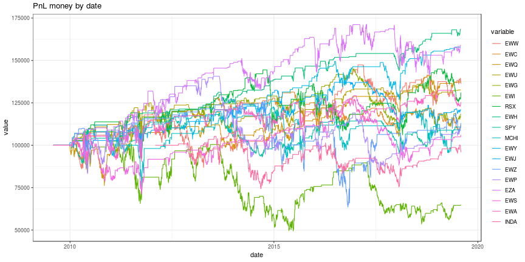

```r
plotPnL(models, interactive_plot=FALSE)
```

If we have a list of models then we can create a portfolio of models. Backtests will be summed inside it and plotPnL will draw summed profit and loss graph. Most of all reporting, optimization and performing functions working with list and modelPortfolio as well as with modelStrategy.

```r
portfolio <- modelPortfolio(models)
performServer(portfolio)
getReportStrategy(portfolio)
```

```
#>                      [,1]
#> trades               1181.000000
#> trades.year           158.000000
#> total.acc               0.886537
#> max.loose               5.000000
#> max.win                56.000000
#> return.ann             -0.000310
#> return.avg             -0.012239
#> return.pos.drawdown    -0.003319
#> drawdown.money          0.253725
#> days.in.drawdown     1977.000000
#> median                  0.000453
#> days.in.pos.max       508.000000
#> days.in.pos.mean       19.133785
#> sharpe.ann             -0.039877
#> sortino.ann            -0.081445
#> maxMAE.money            0.356881
#> profit.drawdown.year   -0.016402
```

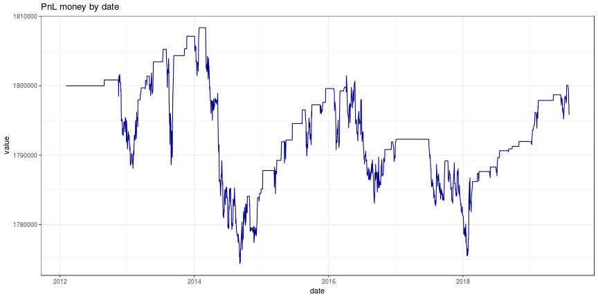

```r
plotPnL(portfolio, interactive_plot=FALSE)
```

## Pair strategy

Let's move on. We saw that discussed mean-reverting strategy does not work well with considered assets. We will give a try for a pair of them. We will create a spread. As we mentioned above we should define a table. It will be adjusted prices. Then we should define a function that will calculate coefficients. This function will take this table as an argument and should return the number of assets to buy and sell. These numbers may not be integers, backtester will round them by itself. Also, we should define how many rows of this table to use. To do that there is a function `setLookback`. Let's use 2 years of previously seen data, it is approximately 500 points. And we should say to model how often recalculate coefficients. `setLookforward` function is responsible for that. Let's use 10 points. By default if the position was opened and we are at the last point of lookforward period, then spread will be calculated with the same coefficients and then will be recalculated after the closing of the position. To turn off this option you can use `setIgnorePosition(this, TRUE)`. We will use the previous function for creating the model and just add the rule for creating coefficients.

```r
this <- createMeanRevertingModel()
setLookback(this, 500)
setLookForward(this, 10)
setBeta(this, function(data, ...){ # dots are arguments, that we do not use,
    #data is a matrix, that includes lookback + 1 rows
    # Here we define how we will calculate coefficients
    # We will do that with help of linear regression
    colnames(data) <-  c('x', 'y')

    # define the model
    model <- lm(y~x, data.frame(data))

    # get coefficients
    beta <- c(1, -coefficients(model)[2])

    # return coefs, program automatically round them, you can cancel this behavior with function setBetasInt(this, FALSE),
    # but you have to round them by yourself, if you don't do that, the program will work incorrectly
    return(beta)
})
```

Now we should add data to our model. We can add data in the format of a list of xts tables.

```r
pair <- c("EWH", "EWS")
setUserData(this, data[pair])
```

Let's evaluate the model and see the results.

```r
performServer(this)
getReportStrategy(this)
```

```
#>                      [,1]
#> trades                58.00000
#> trades.year            6.00000
#> long.trades           26.00000
#> short.trades          32.00000
#> long.acc               0.96154
#> short.acc              0.84375
#> total.acc              0.89655
#> max.loose              2.00000
#> max.win               21.00000
#> return.ann             0.01968
#> return.avg             0.05888
#> return.pos.drawdown    0.01651
#> drawdown.money         0.07664
#> days.in.drawdown     528.00000
#> median                 0.00434
#> in.pos                 0.33626
#> in.pos.positive        0.12877
#> days.in.pos.max      156.00000
#> days.in.pos.mean      21.15517
#> days.out.pos.max     141.00000
#> days.out.pos.mean     29.59649
#> sharpe.ann             0.40539
#> sortino.ann            0.73042
#> maxMAE.money           0.07664
#> profit.drawdown.year   0.23909
```

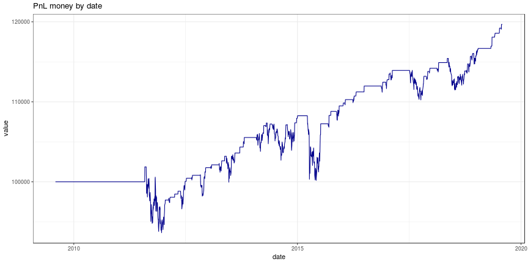

```r
plotPnL(this, interactive_plot=FALSE)
```

## Basket of assets

Let's backtest such a strategy that buys an asset for half of the money with the lowest value of RSI oscillator and sells an asset for another half of money with the highest value of RSI. RSI will be calculated from adjusted close prices. In the previous example, we used setBeta for calculating coefficients for 10 steps ahead. Now we will use it just for 1 step and will set ignoring position after the end of the period. The rule for this strategy will be as simple as possible – always TRUE.

```r
this <- modelStrategy()
setLookback(this, 1)
setLookForward(this, 1)
setIgnorePosition(this, TRUE)
addRule(this, as = 'long',
        condition = TRUE,
        type = 'enter',
        side = 1,
        oco = 'long'
)
```

Now it's time to present function `addProgramPart`. It serves us for ability to add your code into backtester. There are many places where you can add code. For now, we need a place, where data tables are defined. We need to calculate RSI. In the backtester as mentioned before there are inner variables. One of them is `modelD`. It is an environment and it stores tables of data. In the cell `data_raw` it has downloaded data that we passed to our strategy object. So we need to create a new data table, we call it “RSI”, and make it equal to RSI applied to every column of “data_raw” cell of object `modelD`. We will use this table in `setBeta` function, so we should write `setBetaData(this, 'RSI')`. After that “RSI” table will be passed to setBeta for getting coefficients.

```r
addProgramPart(this,
               evolution = list(
                 data = quote({
                   modelD[['RSI']] <- apply(modelD[['data_raw']], 2, RSI, n = 20)
                 })
               ))
setBetaData(this, 'RSI')
```

Almost done. It only remains to determine function in `setBeta`. And we can make force coefficients to not be in amount of assets, but in amount of money for each asset with help of `setBetasByMoney(this, TRUE)`.

```r
setBeta(this, function(data, ...){
  # data here is subset of rows of modelD[['RSI']]
  # we need only the last row
  data <- as.numeric(tail(data, 1) )

  # sort the values.
  ord <- order(data)

  # create array of coefficients
  beta <- numeric(length(data))

  # assign 1 to asset with the lowest RSI
  beta[head(ord, 1)] <- 1

  # assign -1 to asset with the highest RSI
  beta[tail(ord, 1)] <- -1
  return(beta)
})
setBetasByMoney(this, TRUE)
```

Also, let's add commissions to our model. It can be done with `setCommission`. The second argument of this function is a quoted expression, that depends on `pos_change` argument. It is equal to difference in position between the current moment and previous in backtest. For example, we can set commissions to the module of change of positions nominal multiplied by 0.0005. To get current prices of assets you can use `data_raw[i,]`. Where `data_raw` stores prices in the format of matrix and its values equal to `modelD[["data_raw"]]`, but `modelD[["data_raw"]]` table is xts a series; `i` is the current moment in backtesting.

```r
setCommission(this, quote({
  abs(pos_change) * data_raw[i,] * 0.0005
}))
```

Let's evaluate the model

```r
setUserData(this, data)
performServer(this)
getReportStrategy(this)
```

```
#>                      [,1]
#> trades               1883.000000
#> trades.year           251.000000
#> long.trades          1883.000000
#> short.trades            0.000000
#> long.acc                0.487520
#> short.acc               0.000000
#> total.acc               0.487520
#> max.loose              10.000000
#> max.win                 9.000000
#> return.ann             -0.010516
#> return.avg             -0.010528
#> return.pos.drawdown    -0.007851
#> drawdown.money          0.339443
#> days.in.drawdown     1539.000000
#> median                 -0.000187
#> in.pos                  0.998904
#> in.pos.positive         0.491401
#> days.in.pos.max         5.000000
#> days.in.pos.mean        1.451407
#> days.out.pos.max        0.000000
#> days.out.pos.mean       0.000000
#> sharpe.ann             -0.089034
#> sortino.ann            -0.189764
#> maxMAE.money            0.030146
#> profit.drawdown.year   -0.030982
```

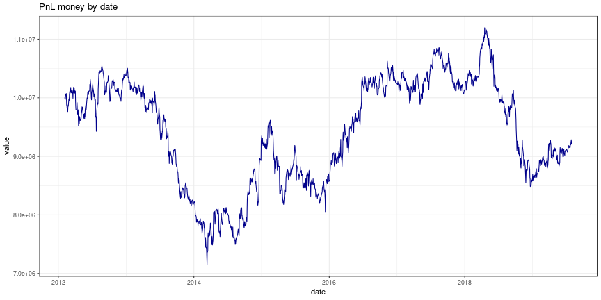

```r
plotPnL(this, interactive_plot=FALSE)
```

This is the end of the introduction. Thank you for reading.